# Plant Informatics

Md. Tabassum Hossain Emon

# **Gene Expression Exploration in Model & Other Plant Species**

**Overall Workflow:**

- Understanding how gene expression data are generated and what the purpose of normalization/summarization is;
- Identifying the sample that has the strongest expression level for a gene of interest;
- Being able to explore gene expression data in other plant species using NCBI Data Viewer;
- Having the means to explore expression of short RNAs and degradation products using the plant informatic database.

## Expression Visualization From the Develpmental Map

**Organism** *Arabidopsis thaliana*

If we don’t see a phenotype under “normal” growth conditions for a mutant line of a particular gene (e.g. a T-DNA insertion line), the expression data for that gene can suggest where or under which conditions to look to be able to see a phenotype. So, from the virtual ePlant I’ve made a query on my gene of interest ABI3. Its expression level is on the peak specifically in **Seeds stage 9 w/o siliques** (1249.81).

The map is colored **Yellow-Red** according to the expression level.

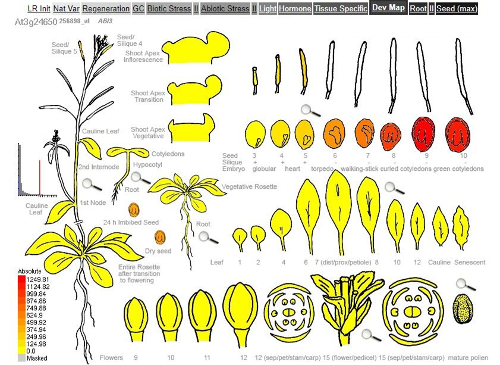

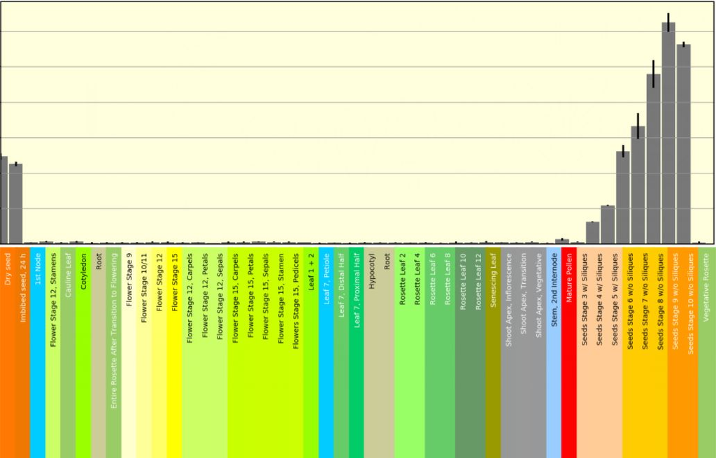

### Data Modelling

Factorial Design Using Group-mean Parameterization Model for Doxorubicine Study;

$Y \:= \:\beta_1 X_1 \:+\: \beta_2 X_2 \:+\:\beta_3 X_3\:+\: \beta_4 X_4\:+\: \epsilon$

- $β_1$ - Mean expression level in top2b mice treated with dox
- $β_2$ - Mean expression level in top2b treated with pbs
- $β_3$ - Mean expression level in wt mice treated with dox
- $β_4$ - Mean expression level in wt mice treated with pbs

#### Contrasts for Doxorubicine Study

- Response of wild type mice to dox treatment: $β_3 − β_4$ = 0
- Response of Top2b null mice to dox treatment: $β_1 − β_2$ = 0
- Differences between Top2b null and wild type mice in response to dox treatment: $(β_1 − β_2) - (β_3 − β_4) = 0$

To test for the effect of doxorubicin on the hearts of wild type and Top2b null mice (and any interaction between treatment and genotype), it’s needed to contrast the coefficients from the design matrix.

### **Pathway Enrichment Analysis**

A work by [Md. Tabassum Hossain Emon](https://md-tabassum-hossain-emon.netlify.app/)

*emon.biotech.10th@gmail.com*